# Practical Lab 2 - Multivariate Linear Regression, Non-Parametric Models and Cross-Validation

# Part 1

## Obtaining the Data

```python
from sklearn import datasets
import pandas as pd
from matplotlib import pyplot as plt
import seaborn as sns
from sklearn.model_selection import train_test_split

diabetes = datasets.load_diabetes()
df = pd.DataFrame(diabetes.data, columns=diabetes.feature_names)
df['progression'] = diabetes.target
print(df.head())
```

```
        age       sex       bmi        bp        s1        s2        s3  \
0  0.038076  0.050680  0.061696  0.021872 -0.044223 -0.034821 -0.043401
1 -0.001882 -0.044642 -0.051474 -0.026328 -0.008449 -0.019163  0.074412
2  0.085299  0.050680  0.044451 -0.005670 -0.045599 -0.034194 -0.032356
3 -0.089063 -0.044642 -0.011595 -0.036656  0.012191  0.024991 -0.036038
4  0.005383 -0.044642 -0.036385  0.021872  0.003935  0.015596  0.008142

         s4        s5        s6  progression
0 -0.002592  0.019907 -0.017646        151.0
1 -0.039493 -0.068332 -0.092204         75.0
2 -0.002592  0.002861 -0.025930        141.0
3  0.034309  0.022688 -0.009362        206.0
4 -0.002592 -0.031988 -0.046641        135.0
```

## Framing the Problem

### Goal:

- The goal of this task is to build a predictive model that helps physicians identify patients at risk of diabetes progression based on their physical and medical characteristics. Specifically, we want to predict the disease progression one year after baseline using the provided features.

### Problem Framing:

- Type of Problem: This is a regression problem since we are predicting a continuous target variable (progression, which represents disease progression one year after baseline).
- Target Variable: The dependent variable (output) we want to predict is progression, which measures the severity of diabetes progression.

## Exploratory Data Analysis (EDA)

### Basic statistics

```python
print(df.describe())
```

```
                age           sex           bmi            bp            s1  \
count  4.420000e+02  4.420000e+02  4.420000e+02  4.420000e+02  4.420000e+02
mean  -2.511817e-19  1.230790e-17 -2.245564e-16 -4.797570e-17 -1.381499e-17
std    4.761905e-02  4.761905e-02  4.761905e-02  4.761905e-02  4.761905e-02
min   -1.072256e-01 -4.464164e-02 -9.027530e-02 -1.123988e-01 -1.267807e-01
25%   -3.729927e-02 -4.464164e-02 -3.422907e-02 -3.665608e-02 -3.424784e-02
50%    5.383060e-03 -4.464164e-02 -7.283766e-03 -5.670422e-03 -4.320866e-03
75%    3.807591e-02  5.068012e-02  3.124802e-02  3.564379e-02  2.835801e-02
max    1.107267e-01  5.068012e-02  1.705552e-01  1.320436e-01  1.539137e-01

                 s2            s3            s4            s5            s6  \
count  4.420000e+02  4.420000e+02  4.420000e+02  4.420000e+02  4.420000e+02
mean   3.918434e-17 -5.777179e-18 -9.042540e-18  9.293722e-17  1.130318e-17
std    4.761905e-02  4.761905e-02  4.761905e-02  4.761905e-02  4.761905e-02
min   -1.156131e-01 -1.023071e-01 -7.639450e-02 -1.260971e-01 -1.377672e-01
25%   -3.035840e-02 -3.511716e-02 -3.949338e-02 -3.324559e-02 -3.317903e-02
50%   -3.819065e-03 -6.584468e-03 -2.592262e-03 -1.947171e-03 -1.077698e-03
75%    2.984439e-02  2.931150e-02  3.430886e-02  3.243232e-02  2.791705e-02
max    1.987880e-01  1.811791e-01  1.852344e-01  1.335973e-01  1.356118e-01

       progression
count   442.000000
mean    152.133484
std      77.093005
min      25.000000
25%      87.000000
50%     140.500000
75%     211.500000
max     346.000000
```

- Most features are normalized, with means near zero and a standard deviation of around 0.0476.
- The average of target variable, progression 152.13, with a wide range (from 25 to 346), indicating significant variability in disease progression.
- Features like bmi, bp, and others show variability within a small range due to normalization.
- Sex and age have narrow ranges, especially for sex, which seems to have values constrained around two distinct values, possibly indicating a binary encoded variable (0 or 1 for male/female or similar).
- Since BMI is an important factor in diabetes management, we expect it to have a strong relationship with the progression score.
- Another key feature likely to influence disease progression, given that hypertension is often associated with diabetes.

### Histogram

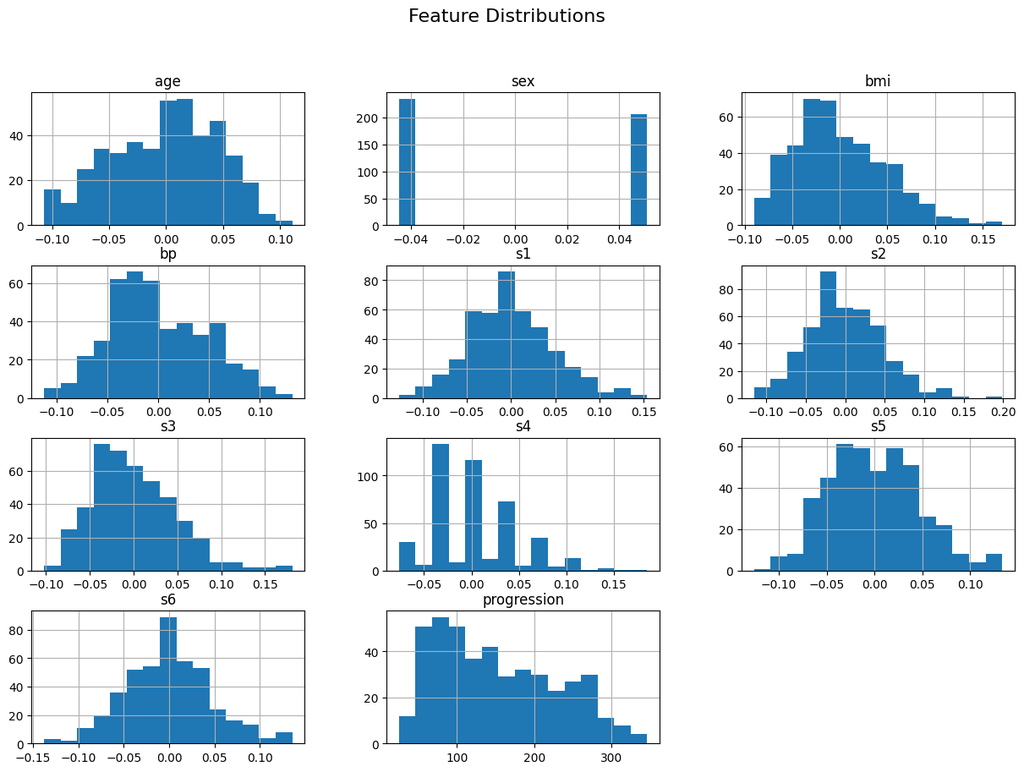

```python
df.hist(bins=15, figsize=(15, 10))
plt.suptitle("Feature Distributions", fontsize=16)
plt.show()
```

- Age: The age feature is approximately normally distributed with a slight skew towards younger ages.
- Sex: This feature appears to be binary, with two distinct values, indicating that it likely represents male and female categories, or a similar binary classification.
- BMI: The body mass index (BMI) feature is approximately normally distributed, with most values centered around 0, indicating that the majority of patients have BMI values close to the average.
- Blood Pressure (bp): Blood pressure also follows a relatively normal distribution, with most patients falling around the mean, indicating a typical variation in blood pressure values.
- Medical Measurements (s1 to s6): These features also appear to be normally distributed, though some (like s4 and s6) show more pronounced peaks, suggesting that certain medical measurements may have more frequent values around a specific range.
- Progression (Target Variable): The disease progression scores are somewhat right-skewed, with more patients having lower progression scores but a noticeable spread towards higher values.
- Most of the features show normal or near-normal distributions.
- The target variable (progression) is skewed to the right, which suggests that a few patients have much higher progression values. That indicates that predicting higher progression might be more difficult for the model.

### ScatterPlot of BMI vs. Progression

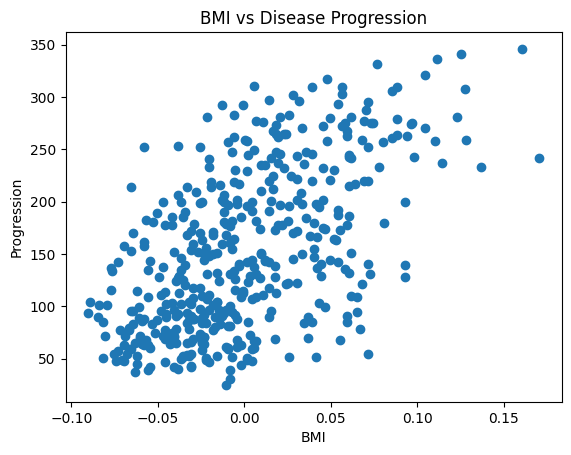

```python
plt.scatter(df['bmi'], df['progression'])
plt.xlabel('BMI')
plt.ylabel('Progression')
plt.title('BMI vs Disease Progression')
plt.show()
```

- There is a visible upward trend, indicating a positive correlation between BMI and disease progression. As BMI increases, the disease progression tends to increase as well.
- The data points are scattered even though there is a positive correlation, suggesting that while BMI is a significant factor, there are other factors contributing to the progression of diabetes.
- Since BMI shows a positive correlation with disease progression, it will likely be a useful predictor in the regression models, but it may need to be combined with other features for more accurate predictions.

### Correlation Matrix

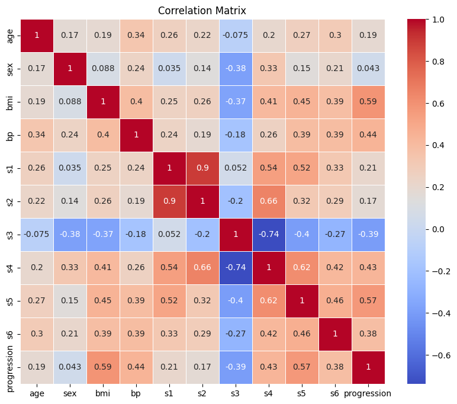

```python
corr_matrix = df.corr()
plt.figure(figsize=(10, 8))
sns.heatmap(corr_matrix, annot=True, cmap='coolwarm', square=True, linewidths=0.5)
plt.title("Correlation Matrix")
plt.show()
```

- BMI has the highest correlation with disease progression, indicating that as BMI increases, disease progression tends to increase as well.
- This medical measurement also shows a strong positive correlation with progression, making it another important feature for predicting disease progression.
- Blood pressure is moderately correlated with progression, suggesting it also plays a role in predicting the outcome.
- BMI, s5, and BP appear to be the most important predictors of disease progression.

### Data Cleaning

#### Checking for missing values

```python
print(df.isnull().sum())
```

```
age            0
sex            0
bmi            0
bp             0
s1             0
s2             0
s3             0
s4             0
s5             0
s6             0
progression    0
dtype: int64
```

#### Checking for outlier

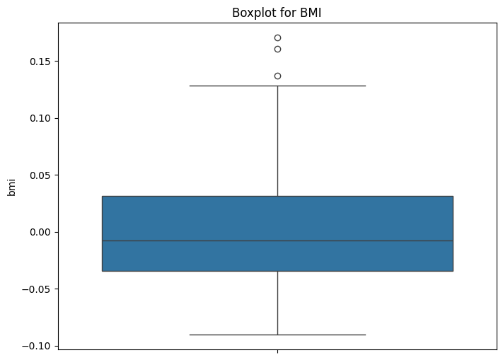

```python
plt.figure(figsize=(8, 6))
sns.boxplot(data=df['bmi'])
plt.title('Boxplot for BMI')
plt.show()
```

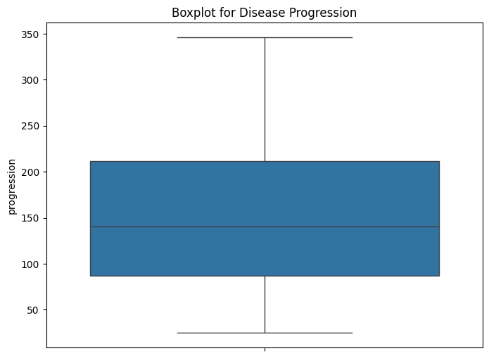

```python
plt.figure(figsize=(8, 6))
sns.boxplot(data=df['progression'])
plt.title('Boxplot for Disease Progression')
plt.show()
```

- There are no missing values to handle (as previously noted), and the few BMI outliers are not extreme enough to warrant removal.
- Keeping the outliers makes sense because they represent real, potentially important cases (e.g., patients with high BMI), and their removal could reduce the generalizability of the model to patients with higher risks.

## Train-Validation-Test Split

```python
X = df.drop('progression', axis=1)
y = df['progression']

X_train, X_temp, y_train, y_temp = train_test_split(X, y, test_size=0.25, random_state=42)
X_val, X_test, y_val, y_test = train_test_split(X_temp, y_temp, test_size=0.6, random_state=42)

print(f"Training set size: {X_train.shape[0]} samples")
print(f"Validation set size: {X_val.shape[0]} samples")
print(f"Test set size: {X_test.shape[0]} samples")
```

```
Training set size: 331 samples
Validation set size: 44 samples
Test set size: 67 samples
```

# Part 2

## Univriate Polynomial Regression(BMI vs. Disease Progression)

```python
from sklearn.preprocessing import PolynomialFeatures
from sklearn.linear_model import LinearRegression
from sklearn.metrics import mean_absolute_error, mean_absolute_percentage_error, r2_score
import numpy as np
```

```python
def fit_poly(degree, X_train, y_train, X_val, y_val):
    poly = PolynomialFeatures(degree=degree)
    X_train_poly = poly.fit_transform(X_train[['bmi']])
    X_val_poly = poly.transform(X_val[['bmi']])

    model = LinearRegression()
    model.fit(X_train_poly, y_train)

    y_train_pred = model.predict(X_train_poly)
    y_val_pred = model.predict(X_val_poly)

    train_r2 = r2_score(y_train, y_train_pred)
    val_r2 = r2_score(y_val, y_val_pred)
    train_mae = mean_absolute_error(y_train, y_train_pred)
    val_mae = mean_absolute_error(y_val, y_val_pred)
    train_mape = mean_absolute_percentage_error(y_train, y_train_pred)
    val_mape = mean_absolute_percentage_error(y_val, y_val_pred)

    return {
        'degree': degree,
        'train_r2': train_r2, 'val_r2': val_r2,
        'train_mae': train_mae, 'val_mae': val_mae,
        'train_mape': train_mape, 'val_mape': val_mape
    }
```

```python
results = []

for degree in range(6):
    res = fit_poly(degree, X_train, y_train, X_val, y_val)
    results.append(res)

import pandas as pd
results_df = pd.DataFrame(results)
print(results_df)
```

```
   degree  train_r2    val_r2  train_mae    val_mae  train_mape  val_mape
0       0  0.000000 -0.106957  66.201641  66.057059    0.628267  0.712639
1       1  0.349672  0.331264  52.287739  47.208472    0.483629  0.470600
2       2  0.350764  0.331631  52.207314  47.213700    0.482985  0.472397
3       3  0.350774  0.331638  52.198968  47.185414    0.482807  0.472227
4       4  0.353014  0.340758  52.092653  46.090118    0.480533  0.460503
5       5  0.354100  0.349881  52.059191  45.462121    0.480040  0.451753
```

- Degree 1 (Linear Model) performs well with R² = 0.350 (train), 0.331 (val) and MAE = 52.29 (train), 47.21 (val). It's simple and performs well.
- Degree 5 (Best Model) has slightly better metrics: R² = 0.354 (train), 0.350 (val) and MAE = 52.06 (train), 45.46 (val). However, the improvement over degree 1 is marginal.

Best Model: Degree 5 is the best performer, but Degree 1 is almost as good and simpler.

## Training The Degree 1 Model

```python
poly = PolynomialFeatures(degree=1)
X_train_poly = poly.fit_transform(X_train[['bmi']])
X_test_poly = poly.transform(X_test[['bmi']])

model = LinearRegression()
model.fit(X_train_poly, y_train)

y_test_pred = model.predict(X_test_poly)
```

## Evaluating the model on the test set

```python
test_r2 = r2_score(y_test, y_test_pred)
test_mae = mean_absolute_error(y_test, y_test_pred)
test_mape = mean_absolute_percentage_error(y_test, y_test_pred)

print(f"Test R-squared: {test_r2}")
print(f"Test MAE: {test_mae}")
print(f"Test MAPE: {test_mape}")
```

```
Test R-squared: 0.2808192775677516
Test MAE: 51.510268892980626
Test MAPE: 0.4317336354937025
```

- R-squared (R²): 0.281 – This means that the model explains about 28.1% of the variance in disease progression based on BMI in the test set. While it's a modest fit, it indicates some relationship between BMI and progression, though other factors are likely influencing progression.
- Mean Absolute Error (MAE): 51.51 – On average, the model's predictions are off by about 51.51 units in disease progression.
- Mean Absolute Percentage Error (MAPE): 43.17% – On average, the model's predictions deviate by about 43% from the actual values in the test set.
- The model performs reasonably well for a simple linear model, but the R² value suggests that additional features (or a more complex model) could better capture the variance in disease progression.
- The error metrics indicate that while the model is capturing the general trend, there is room for improvement, especially in reducing prediction errors.

## Plots

### Plot for Training

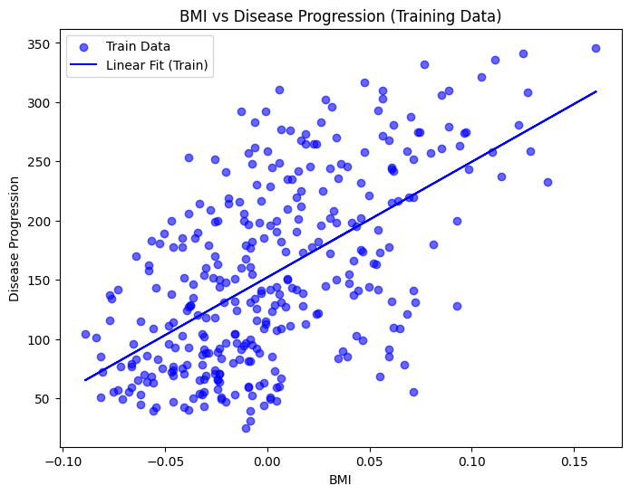

```python
plt.figure(figsize=(8, 6))
plt.scatter(X_train['bmi'], y_train, label='Train Data', color='blue', alpha=0.6)
plt.plot(X_train['bmi'], model.predict(poly.transform(X_train[['bmi']])), label='Linear Fit (Train)', color='blue')
plt.xlabel('BMI')
plt.ylabel('Disease Progression')
plt.title('BMI vs Disease Progression (Training Data)')
plt.legend()
plt.show()
```

- The linear fit captures the general trend well, with a clear positive relationship between BMI and disease progression

### Plot for Validation

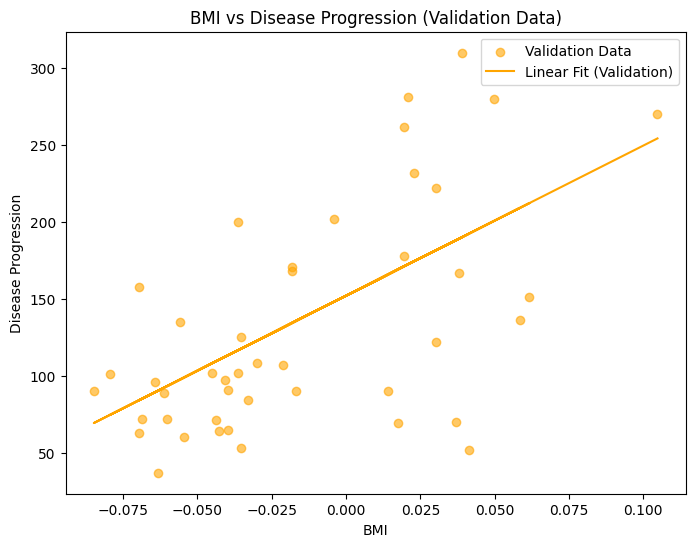

```python
plt.figure(figsize=(8, 6))
plt.scatter(X_val['bmi'], y_val, label='Validation Data', color='orange', alpha=0.6)
plt.plot(X_val['bmi'], model.predict(poly.transform(X_val[['bmi']])), label='Linear Fit (Validation)', color='orange')
plt.xlabel('BMI')
plt.ylabel('Disease Progression')
plt.title('BMI vs Disease Progression (Validation Data)')
plt.legend()
plt.show()
```

- The validation data shows a similar trend, with a good fit for the linear model, but the points are more scattered than in the training data.

### Plot for Test

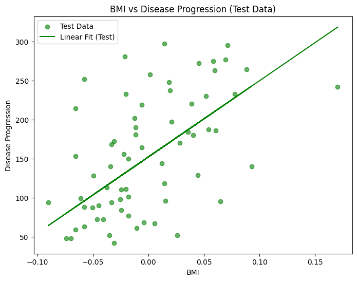

```python
plt.figure(figsize=(8, 6))
plt.scatter(X_test['bmi'], y_test, label='Test Data', color='green', alpha=0.6)
plt.plot(X_test['bmi'], model.predict(poly.transform(X_test[['bmi']])), label='Linear Fit (Test)', color='green')
plt.xlabel('BMI')
plt.ylabel('Disease Progression')
plt.title('BMI vs Disease Progression (Test Data)')
plt.legend()
plt.show()
```

- The test data also follows the linear trend, but with more spread around the line. This is typical since the model has not seen this data before, and the performance still remains reasonable.

## Equation Of The Model

```python
intercept = model.intercept_
coef = model.coef_[1]
print(f"Disease Progression = {intercept:.2f} + {coef:.2f} * BMI")
```

```
Disease Progression = 152.08 + 975.28 * BMI
```

## Calculating Diabetic Progression using model.predict()

```python
bmi_value = 0.1
bmi_value_df = pd.DataFrame({'bmi': [bmi_value]})
bmi_value_transformed = poly.transform(bmi_value_df)
predicted_progression = model.predict(bmi_value_transformed)

print(f"Predicted Disease Progression for BMI = {bmi_value}: {predicted_progression[0]:.2f}")
```

```
Predicted Disease Progression for BMI = 0.1: 249.60
```

## How many trainable parameters are we fitting for each of the models?

- The number of trainable parameters grows with the degree of the polynomial because we are fitting more complex models (higher degrees add more features derived from BMI).
- Intercept: Every polynomial model has an intercept (constant term).
- Coefficients: The number of coefficients depends on the degree of the polynomial.
- Degree 0: 1 parameter (just the intercept).
- Degree 1: 2 parameters (intercept + BMI coefficient).
- Degree 2: 3 parameters (intercept, BMI, BMI²).
- Degree 3: 4 parameters (intercept, BMI, BMI², BMI³).
- Degree 4: 5 parameters.
- Degree 5: 6 parameters.

```python
for degree in range(6):
    poly = PolynomialFeatures(degree=degree)
    X_train_poly = poly.fit_transform(X_train[['bmi']])

    feature_names = poly.get_feature_names_out(['bmi'])

    num_parameters = len(feature_names)

    print(f"Degree {degree}: {num_parameters} trainable parameters")
    print(f"Features: {feature_names}")
```

```
Degree 0: 1 trainable parameters
Features: ['1']
Degree 1: 2 trainable parameters
Features: ['1' 'bmi']
Degree 2: 3 trainable parameters
Features: ['1' 'bmi' 'bmi^2']
Degree 3: 4 trainable parameters
Features: ['1' 'bmi' 'bmi^2' 'bmi^3']
Degree 4: 5 trainable parameters
Features: ['1' 'bmi' 'bmi^2' 'bmi^3' 'bmi^4']
Degree 5: 6 trainable parameters
Features: ['1' 'bmi' 'bmi^2' 'bmi^3' 'bmi^4' 'bmi^5']
```

## Conclusion

Model Performance:

- The degree 1 (linear) model was chosen as the best model due to its simplicity and reasonable performance.
- On the test set, the model achieved:
  - R-squared (R²): 0.281, indicating that the model explains 28.1% of the variance in disease progression.
  - Mean Absolute Error (MAE): 51.51, suggesting that the model's predictions are, on average, off by about 51 units of disease progression.
  - Mean Absolute Percentage Error (MAPE): 43.17%, meaning that the model's predictions deviate by about 43% from the actual values.

Model Equation: Disease Progression=152.08+975.28⋅BMI

Model Limitations:

- R² = 0.281: The model explains only 28.1% of the variation in disease progression, suggesting that other factors (beyond BMI) are influencing the outcome.
- While the linear model was chosen for simplicity, higher-degree polynomial models may have captured more complex relationships between BMI and disease progression.
- Using higher-degree polynomial models could introduce overfitting, especially with smaller datasets, so the simplicity of the degree 1 model is beneficial in this case.

Conclusion:

- The linear model demonstrates a clear positive relationship between BMI and disease progression, making it a simple and interpretable tool for predicting disease progression. However, the model's modest R² score highlights the need to include more features to improve prediction accuracy and better understand the factors contributing to diabetes progression.

# Part 3

## Data Preparation

```python
X = df.drop('progression', axis=1)
y = df['progression']
X_train, X_temp, y_train, y_temp = train_test_split(X, y, test_size=0.25, random_state=42)
X_val, X_test, y_val, y_test = train_test_split(X_temp, y_temp, test_size=0.6, random_state=42)
```

## Polynomial Regression Model

### Polynomial Model 1: Degree 2

```python
from sklearn.preprocessing import PolynomialFeatures
from sklearn.linear_model import LinearRegression

poly_2 = PolynomialFeatures(degree=2)
X_train_poly_2 = poly_2.fit_transform(X_train)
X_val_poly_2 = poly_2.transform(X_val)

model_poly_2 = LinearRegression()
model_poly_2.fit(X_train_poly_2, y_train)

y_val_pred_poly_2 = model_poly_2.predict(X_val_poly_2)

val_r2_poly_2 = r2_score(y_val, y_val_pred_poly_2)
val_mae_poly_2 = mean_absolute_error(y_val, y_val_pred_poly_2)
val_mape_poly_2 = mean_absolute_percentage_error(y_val, y_val_pred_poly_2)

print(f"Polynomial Degree 2 - Validation R²: {val_r2_poly_2:.4f}, MAE: {val_mae_poly_2:.4f}, MAPE: {val_mape_poly_2:.4f}")
```

```
Polynomial Degree 2 - Validation R²: -1.6777, MAE: 90.0682, MAPE: 0.9549
```

### Polynomial Model 2: Degree 3

```python
poly_3 = PolynomialFeatures(degree=3)
X_train_poly_3 = poly_3.fit_transform(X_train)
X_val_poly_3 = poly_3.transform(X_val)

model_poly_3 = LinearRegression()
model_poly_3.fit(X_train_poly_3, y_train)

y_val_pred_poly_3 = model_poly_3.predict(X_val_poly_3)

val_r2_poly_3 = r2_score(y_val, y_val_pred_poly_3)
val_mae_poly_3 = mean_absolute_error(y_val, y_val_pred_poly_3)
val_mape_poly_3 = mean_absolute_percentage_error(y_val, y_val_pred_poly_3)

print(f"Polynomial Degree 3 - Validation R²: {val_r2_poly_3:.4f}, MAE: {val_mae_poly_3:.4f}, MAPE: {val_mape_poly_3:.4f}")
```

```
Polynomial Degree 3 - Validation R²: -45.3835, MAE: 243.5682, MAPE: 2.1656
```

## Decision Tree Models

### Decision Tree Model 1: max_depth=3

```python
from sklearn.tree import DecisionTreeRegressor

tree_3 = DecisionTreeRegressor(max_depth=3)
tree_3.fit(X_train, y_train)

y_val_pred_tree_3 = tree_3.predict(X_val)

val_r2_tree_3 = r2_score(y_val, y_val_pred_tree_3)
val_mae_tree_3 = mean_absolute_error(y_val, y_val_pred_tree_3)
val_mape_tree_3 = mean_absolute_percentage_error(y_val, y_val_pred_tree_3)

print(f"Decision Tree (max_depth=3) - Validation R²: {val_r2_tree_3:.4f}, MAE: {val_mae_tree_3:.4f}, MAPE: {val_mape_tree_3:.4f}")
```

```
Decision Tree (max_depth=3) - Validation R²: 0.1983, MAE: 48.1262, MAPE: 0.4767
```

### Decision Tree Model 2: max_depth=5

```python
tree_5 = DecisionTreeRegressor(max_depth=5)
tree_5.fit(X_train, y_train)

y_val_pred_tree_5 = tree_5.predict(X_val)

val_r2_tree_5 = r2_score(y_val, y_val_pred_tree_5)
val_mae_tree_5 = mean_absolute_error(y_val, y_val_pred_tree_5)
val_mape_tree_5 = mean_absolute_percentage_error(y_val, y_val_pred_tree_5)

print(f"Decision Tree (max_depth=5) - Validation R²: {val_r2_tree_5:.4f}, MAE: {val_mae_tree_5:.4f}, MAPE: {val_mape_tree_5:.4f}")
```

```
Decision Tree (max_depth=5) - Validation R²: 0.0939, MAE: 49.6455, MAPE: 0.4816
```

## k-Nearest Neighbors (kNN) Models

### kNN Model 1: n_neighbors=3

```python
from sklearn.neighbors import KNeighborsRegressor

knn_3 = KNeighborsRegressor(n_neighbors=3)
knn_3.fit(X_train, y_train)

y_val_pred_knn_3 = knn_3.predict(X_val)

val_r2_knn_3 = r2_score(y_val, y_val_pred_knn_3)
val_mae_knn_3 = mean_absolute_error(y_val, y_val_pred_knn_3)
val_mape_knn_3 = mean_absolute_percentage_error(y_val, y_val_pred_knn_3)

print(f"kNN (n_neighbors=3) - Validation R²: {val_r2_knn_3:.4f}, MAE: {val_mae_knn_3:.4f}, MAPE: {val_mape_knn_3:.4f}")
```

```
kNN (n_neighbors=3) - Validation R²: 0.2142, MAE: 45.7955, MAPE: 0.4424
```

### kNN Model 2: n_neighbors=5

```python
knn_5 = KNeighborsRegressor(n_neighbors=5)
knn_5.fit(X_train, y_train)

y_val_pred_knn_5 = knn_5.predict(X_val)

val_r2_knn_5 = r2_score(y_val, y_val_pred_knn_5)
val_mae_knn_5 = mean_absolute_error(y_val, y_val_pred_knn_5)
val_mape_knn_5 = mean_absolute_percentage_error(y_val, y_val_pred_knn_5)

print(f"kNN (n_neighbors=5) - Validation R²: {val_r2_knn_5:.4f}, MAE: {val_mae_knn_5:.4f}, MAPE: {val_mape_knn_5:.4f}")
```

```
kNN (n_neighbors=5) - Validation R²: 0.3585, MAE: 43.2909, MAPE: 0.4124
```

### Summary

kNN (n_neighbors=5):

- R²: 0.3585
- MAE: 43.29
- MAPE: 41.24%
- Performance: This model performed the best among all models in terms of R² and MAE, suggesting that it's capturing more variance in the data.

kNN (n_neighbors=3):

- R²: 0.2142
- MAE: 45.80
- MAPE: 44.24%
- Performance: Slightly worse than kNN with 5 neighbors, with lower R² and higher error metrics.

Decision Tree (max_depth=5):

- R²: 0.0939
- MAE: 49.65
- MAPE: 48.16%
- Performance: This model has a low R² and high error rates, indicating poor performance and overfitting at higher depths.

Decision Tree (max_depth=3):

- R²: 0.1983
- MAE: 48.13
- MAPE: 47.67%
- Performance: Better than the deeper tree but still not as good as kNN. The model appears to generalize slightly better with a smaller depth.

Polynomial Degree 3:

- R²: -45.3835 (negative R² indicates a terrible fit)
- MAE: 243.57
- MAPE: 216.56%
- Performance: Extremely poor performance with huge errors, indicating the model is overfitting severely.

Polynomial Degree 2:

- R²: -1.6777 (negative R² again indicates a poor fit)
- MAE: 90.07
- MAPE: 95.49%
- Performance: While slightly better than degree 3, this model still performs poorly with high error rates and a negative R².

Conlusion

- The kNN model with 5 neighbors performed the best across all metrics (R², MAE, MAPE). It captured more variance and had the lowest error rates.
- Both polynomial models (degree 2 and 3) performed very poorly, likely overfitting the data.
- The decision trees did not perform well, with relatively low R² and high error rates, especially at higher depths.

## Testing the kNN (n_neighbors=5) Model on the Test set

```python
y_test_pred_knn_5 = knn_5.predict(X_test)

test_r2_knn_5 = r2_score(y_test, y_test_pred_knn_5)
test_mae_knn_5 = mean_absolute_error(y_test, y_test_pred_knn_5)
test_mape_knn_5 = mean_absolute_percentage_error(y_test, y_test_pred_knn_5)

print(f"kNN (n_neighbors=5) - Test R²: {test_r2_knn_5:.4f}")
print(f"kNN (n_neighbors=5) - Test MAE: {test_mae_knn_5:.4f}")
print(f"kNN (n_neighbors=5) - Test MAPE: {test_mape_knn_5:.4f}")
```

```
kNN (n_neighbors=5) - Test R²: 0.4765
kNN (n_neighbors=5) - Test MAE: 41.7194
kNN (n_neighbors=5) - Test MAPE: 0.3446
```

- The kNN (n_neighbors=5) model performs well on the test set, with an R² of 0.4765 and relatively low errors (MAE of 41.72 and MAPE of 34.46%).
- This suggests that the model generalizes well to unseen data, making it a suitable choice for predicting disease progression based on the available features.